# R Cheatsheet Notebook by Soyoung Park

Updated May 31, 2017

[R Markdown](http://rmarkdown.rstudio.com) Notebook.

### shortcuts

- ctrl+L: clear console
- rm(list=ls()) #remove all the variables from the workspace
- getwd()
- setwd(“~/Desktop/Statistics_with_R_Duke/1_Introduction to Probability and Data/project/”)
- *Run* button within the chunk or *Cmd+Shift+Enter*.
- Add a new chunk : *Insert Chunk* or by *Cmd+Option+I*.
- click the *Preview* button or press *Cmd+Shift+K* to preview the HTML file).

```r
#install.packages("dplyr")
#load("brfss2013.RData")
library(ggplot2)
library(dplyr)
```

### Lattice

http://www.isid.ac.in/~deepayan/R-tutorials/labs/04_lattice_lab.pdf

### Keyboard shortcut

https://support.rstudio.com/hc/en-us/articles/200711853-Keyboard-Shortcuts

### R commands

https://www.personality-project.org/r/r.commands.html

### R multivariate

http://little-book-of-r-for-multivariate-analysis.readthedocs.io/en/latest/src/multivariateanalysis.html #ggplot2 Version of Figures in Lattice: Multivariate Data Visualization with R https://learnr.files.wordpress.com/2009/08/latbook.pdf

### ggplot2 doc

http://ggplot2.tidyverse.org/reference/#section-plot-basics

### packages

- Package ‘mlmRev’:Multilevel Modelling https://cran.r-project.org/web/packages/mlmRev/mlmRev.pdf
- Package ‘nlme’:Fit and compare Gaussian linear and nonlinear mixed-effects models https://cran.r-project.org/web/packages/nlme/nlme.pdf
- Package ‘GGally’: ‘GGally’ extends ‘ggplot2’ by adding several functions to reduce the complexity of combining geometric objects with transformed data. Some of these functions include a pairwise plot matrix, a two group pairwise plot matrix, a parallel coordinates plot, a survival plot, and several functions to plot networks. https://cran.r-project.org/web/packages/GGally/GGally.pdf

```r
library(GGally)
```

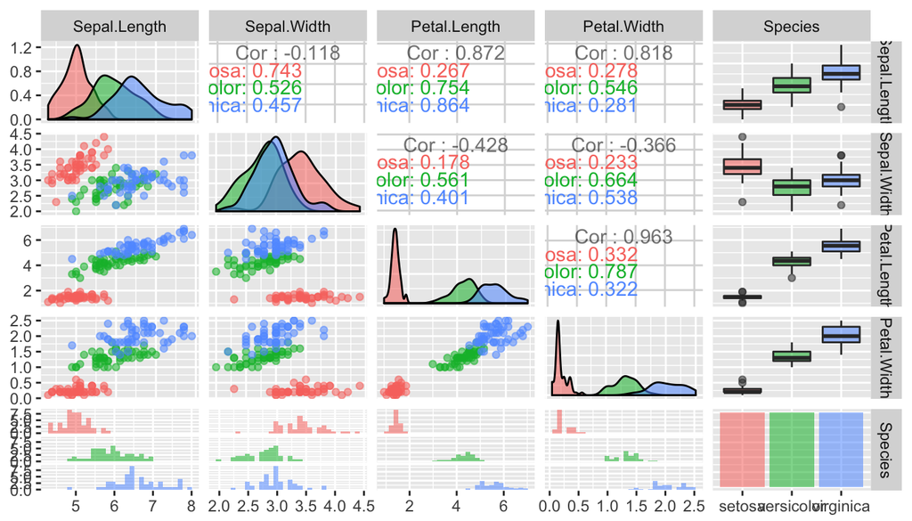

```r
library(ggplot2)
data("iris")
ggpairs(iris, aes(colour = Species, alpha = 0.4))
```

- Package ‘googleVis’ https://cran.rstudio.com/web/packages/googleVis/googleVis.pdf R interface to Google’s chart tools, allowing users to create interactive charts based on data frames. Charts are displayed locally via the R HTTP help server. A modern browser with an Internet connection is required and for some charts a Flash player. The data remains local and is not uploaded to Google. https://developers.google.com/chart/

### Summary of Useful packages:

https://support.rstudio.com/hc/en-us/articles/201057987-Quick-list-of-useful-R-packages

### Gaston Sanchez

http://gastonsanchez.com/blog https://gastonsanchez.wordpress.com/2012/08/27/scatterplot-matrices-with-ggplot/